# 挺进大别山2.0大金融与大消费全面进攻

Quandl WU LIXIN

2019-11-22

## 前言

基于投资策略与投资战略,大数据驱动的定量分析与情感分析驱动的定性分析完美结合,算法,算力,数据成为第一生产力.

三大占位：风口浪尖,火山口,黄金坑.占据天时地利人和;

五大战略：数据驱动,价值驱动,事件驱动,热点驱动,策略驱动;

金木水火土五行八卦：大金融,大消费,油气供热,大基建,黑科技;

# 大消费领域

大消费作为典型的大牛股板块主要监控白酒,医药,酱油,电器.走出多只大牛股,如美的电器,海天味业,五粮液,茅台,酒鬼酒.

## 白酒帝国

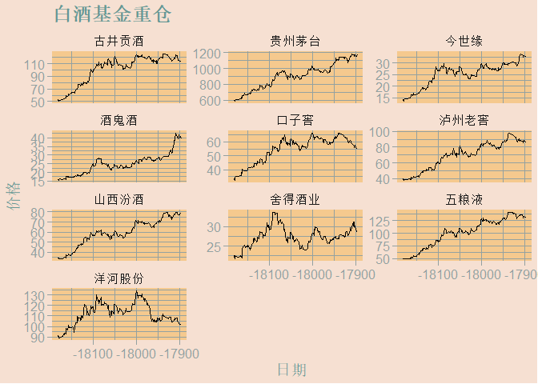

## 医药健康

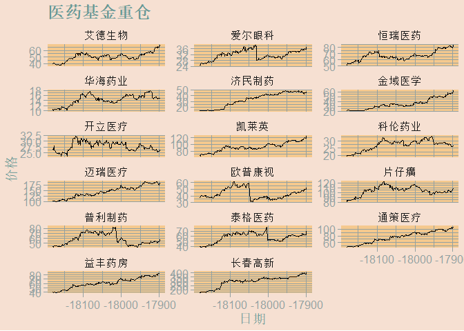

## 家用电器

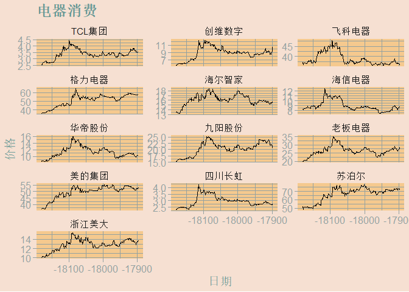

## 酱油调味品

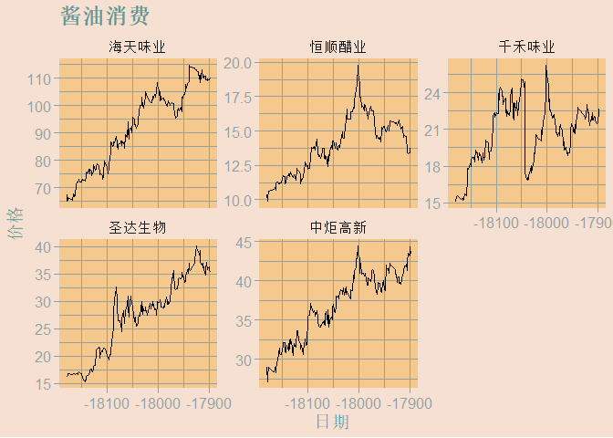

# 大金融领域

大金融作为典型的周期性投资股票,涵盖了金融属性的股票,银行,保险,券商,地产四大主要领域. 中国平安，招商银行,平安银行,宁波银行,中信建投,保利地产,金科股份等等！！多只大牛股.

## 银行集团

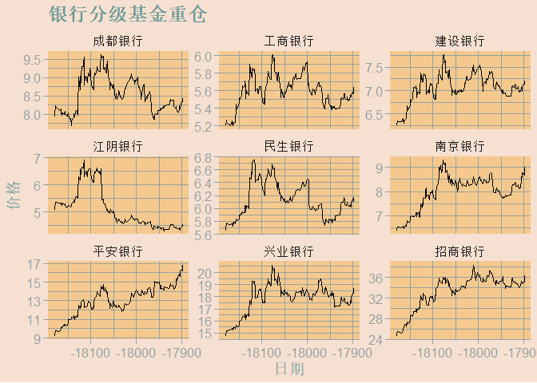

## 保险帝国

保险改革越来越受到政策供给端的影响,险资在股市中扮演着越来越重要的角色.中国平安,中国人寿等多只大牛股脱颖而出！！

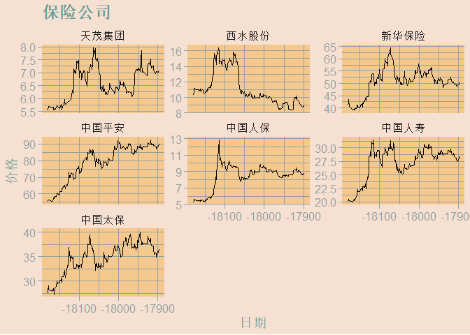

## 证券集团

牛市旗手,牛市风向标,反弹先锋,中信建投,红塔证券一马当先！

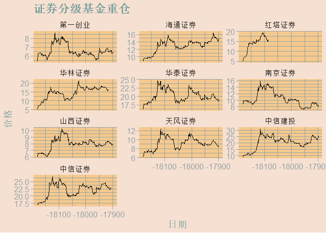

## 地产集团

房地产不仅仅是房地产属性,房子作为人们占比最大的固定资产,房子具有很强的金融投资属性！

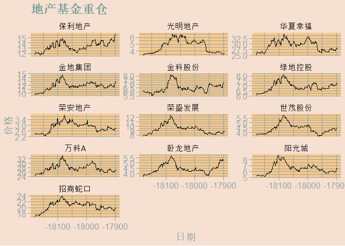

```
风险最大时,也是机遇最大时.别人恐惧时,我们要贪婪！！
```

# 投资大师的成功法则

大师最初也是初学者,跟随大师的脚步才能快速成长.

> “集中投资就是计划生育:股票越少，组合业绩越好;长期持有就是龟兔赛跑:长期内复利可以战胜一切;”

# 投资建议

> 1 采用金字塔式投资策略,震荡的行情中按比例1:2:3:4分布建仓！

> 2 延长持有周期,追求一定周期内的绝对投资回报！

> 3 投资有风险,投资需谨慎！！